# Validation of trajectory sampler

This document describes several validation tests that have been performed on the trajectory sampling system of bdmm-prime. This system allows for post-MCMC sampling of birth-death trajectories. Ideally it should work for any of the models that bdmm-prime itself supports, including models with

- multi-$\rho$-sampling,
- sampled ancestors (generated by either $\psi$- or $\rho$-sampling events),
- multiple types.

To support the sampling of trajectories for multiple types, the method relies on the stochastic mapping algorithm already implemented in bdmm-prime.

# Validation strategies

We will use two main strategies for validation of the trajectory sampler:

1. comparison of the tree probability computed by the importance sampler with a value computed by integrating the KBE, and
2. comparison of the trajectories sampled conditional on each of an ensemble of simulated trees with the distribution of unconditioned trajetories.

The first strategy is straightforward for uncoloured trajectories, as the BDMM-prime tree prior can be used to provide the comparision probability. For the case of coloured trajectories, we’ll instead rely on an independent R implementation of the KBE integration and use this validation only for specific small coloured trees (as the integration procedure is hard-coded).

The second strategy is in some ways superior, as it directly tests the validity of the conditional trajectory distribution sampled by the algorithm. However it is slightly harder to detect deviations from the truth, as it requires comparing two distributions of highly multi-dimensional samples.

# Single-type trajectories

For the single-typed models we will perform both kinds of validation.

In each case we will simulate 1000 trees and trajectories under a BD model, then use the conditional trajectory sampler to produce a second set of 1000 trees under the same distribution. We will then these two distributions, as well as the tree probability estimates for each of the simulated trees.

## Simple validation

To begin, let’s look at a very simple single-type birth-death-sampling model with the following parameters:

- $\lambda = 2$
- $\mu = 1$
- $\psi = 0.5$
- $T = 5$

where $T$ is the length of the trajectory simulation.

First we run the simulations and sample the trajectories:

```bash
pushd single_type
java -jar ../../../out/artifacts/bdmm_prime_jar/bdmm-prime.jar \
     -overwrite traj_and_tree_simulator_1type.xml
java -jar ../../../out/artifacts/bdmm_prime_jar/bdmm-prime.jar \
     -overwrite traj_inference_1type.xml
popd
```

Now we can load in the data and compare the probability estimates generated as part of the conditioned trajectory sampling with those computed using bdmm-prime’s KBE integration (analytical in the single-type case):

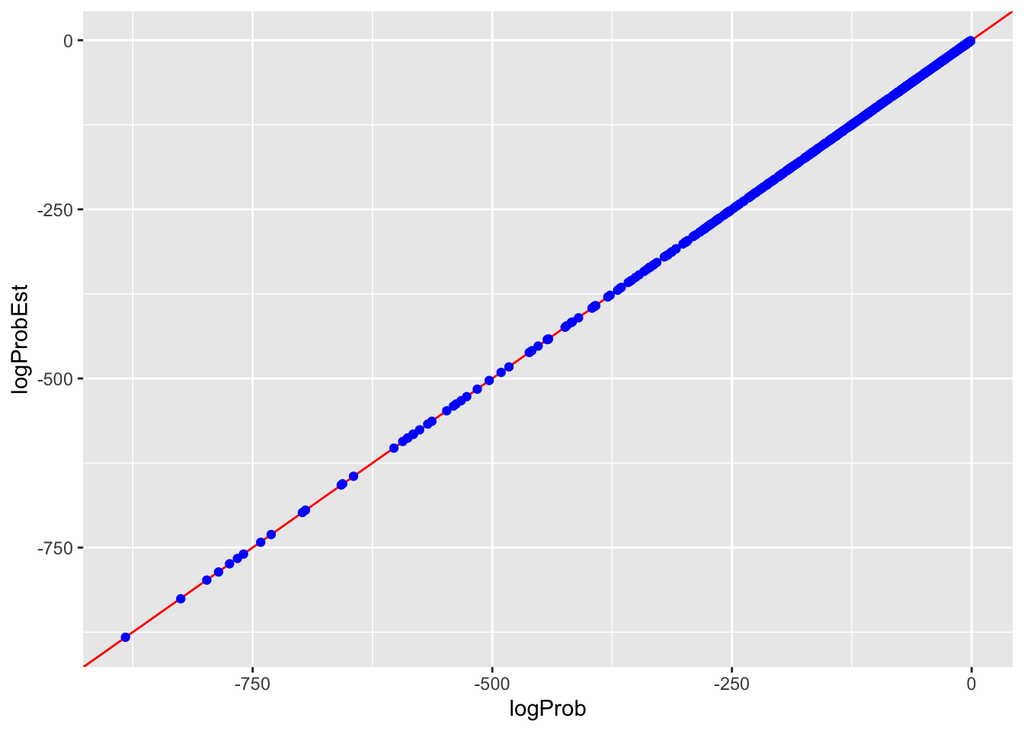

```r
dat <- read_tsv("single_type/traj_inference_1type.log")
ggplot(dat, aes(x=logProb, y=logProbEst)) + geom_abline(col='red') + geom_point(col='blue')
```

These results look quite convincing. How about when we focus on the differences?

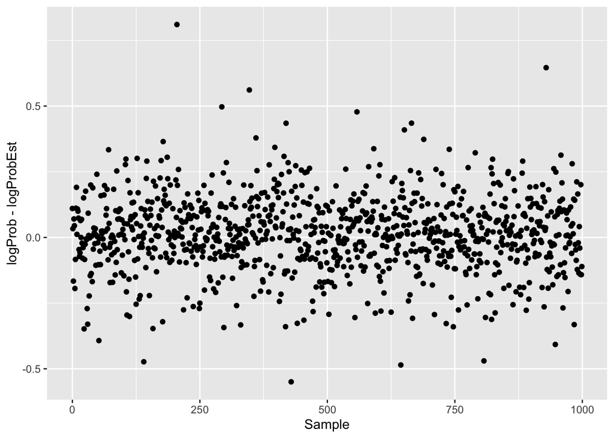

```r
ggplot(dat) + geom_point(aes(Sample, logProb-logProbEst))
```

Now let’s look at the distribution of the actual trajectories.

```r
source("../../scripts/trajProcessing.R")

trajTrue <- loadTrajectories("single_type/traj_and_tree_simulator_1type.traj")
trajSamp <- loadTrajectories("single_type/traj_inference_1type.traj")

times <- seq(0, 5, length.out=51)

traj <- bind_rows(gridTrajectories(trajTrue, times) %>% mutate(ensemble="Original"),
                  gridTrajectories(trajSamp, times) %>% mutate(ensemble="Filter"))
```

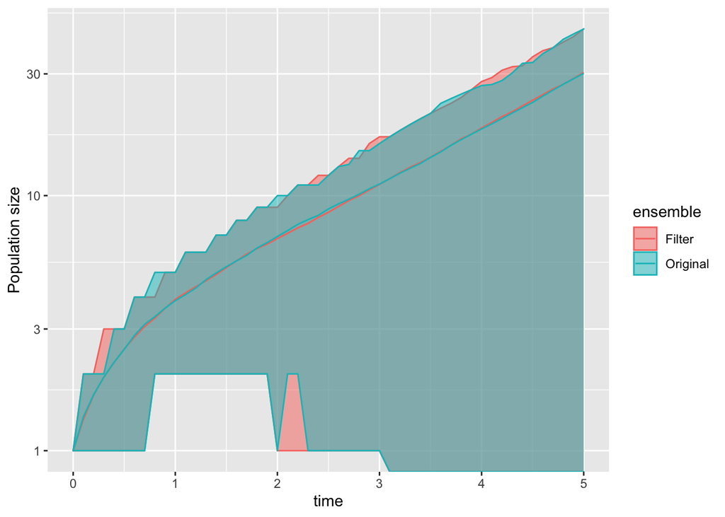

```r
ggplot(traj %>%
       group_by(time, ensemble) %>%
       summarize(mean=mean(N), low=quantile(N, 0.25), high=quantile(N, 0.75))) +
    geom_ribbon(aes(time, ymin=low, ymax=high, fill=ensemble, color=ensemble), alpha=0.5) +
    geom_line(aes(time, mean, color=ensemble)) +
    ylab("Population size") +
    scale_y_log10()
```

Apart from noise due to the finite number of samples, these two distributions appear to be equivalent, indicating that - for this model - the implementation is correct.

## Sampled-ancestor validation

## Multi-$\rho$-sampling validation

# Multi-type trajectories

## Simple sampling strategy validation